# Intro to Data Science - HW 6

## Step 3: Visualize the data

8. Plot points (on top of a map of the US) for **each city**. Have the **color** represent the **population**.

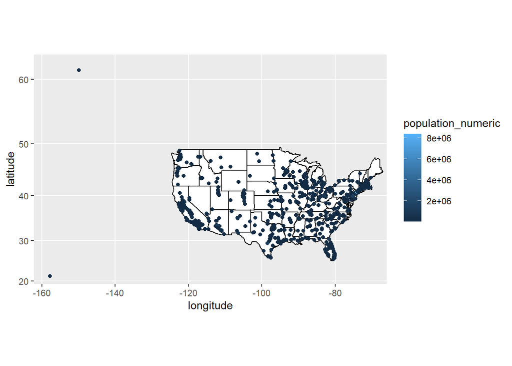

```r
library(ggplot2)
library(maps)
library(ggmap)
library(mapproj)
Step3PartH <- ggplot(dfNew,aes(x=longitude,y=latitude,map_id = tolower(state))) + geom_map(map=map_data("state"),color = "black",fill = "white") + expand_limits(x=dfNew$longitude,y=dfNew$latitude) + coord_map() + geom_point(aes(color=population_numeric))
Step3PartH
```

1. Add a block comment that criticizes the resulting map. It’s not very good.

```r
#This map has a couple points far outside of the continental United States, resulting in the map not being focused on the continental United States. This makes it more difficult to see the distance between any two points and makes the points stack on top of each other more than they would if we were more zoomed in. Also, the color scale is not contrasting enough to truly be effective in showing any differences between city populations.
```

## Step 4: Group by State

10. Use group_by and summarise to make a dataframe of state-by-state population. Store the result in **dfSimple**.

```r
dfSimple <- dfNew %>% group_by(state) %>% summarise(population = sum(population_numeric))

#Let's see how that went...
dfSimple
```

```
## # A tibble: 51 x 2
##    state                population
##    <chr>                     <dbl>
##  1 Alabama                 1279813
##  2 Alaska                   300950
##  3 Arizona                 4691466
##  4 Arkansas                 787011
##  5 California             27910620
##  6 Colorado                3012284
##  7 Connecticut             1239817
##  8 Delaware                 108891
##  9 District of Columbia     646449
## 10 Florida                 7410114
## # ... with 41 more rows
```

```r
#Looks good!!
```

11. Name the most and least populous states in **dfSimple** and show the code you used to determine them.

```r
#Most Populous State:
dfSimple[dfSimple$population == max(dfSimple$population),"state"]
```

```
## # A tibble: 1 x 1
##   state
##   <chr>
## 1 California
```

```r
#California is the most populous state according to these data.

#Least Populous State:
dfSimple[dfSimple$population == min(dfSimple$population),"state"]
```

```
## # A tibble: 1 x 1
##   state
##   <chr>
## 1 Vermont
```

```r
#Vermont is the least populous state according to these data.
```

## Step 5: Create a map of the U.S., with the color of the state representing the state population

12. Make sure to expand the limits correctly and that you have used **coord_map** appropriately.

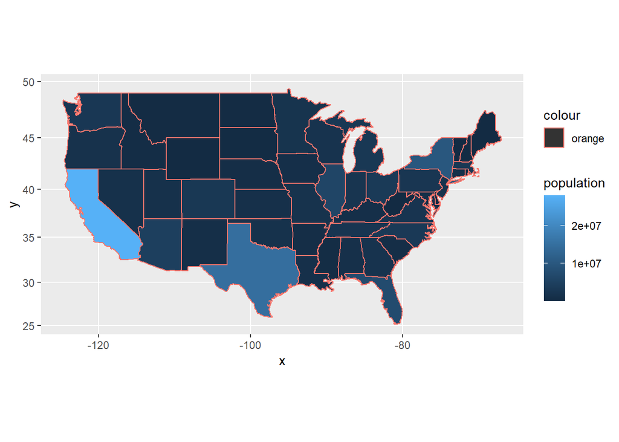

```r
Step5 <- ggplot(dfSimple,aes(map_id = tolower(state))) + geom_map(map = map_data("state"),aes(color = "orange",fill = population)) + expand_limits(x=map_data("state")$long,y=map_data("state")$lat) + coord_map()
Step5
```